# Project: Identify Customer Segments

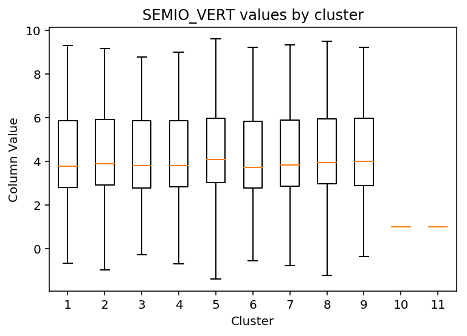

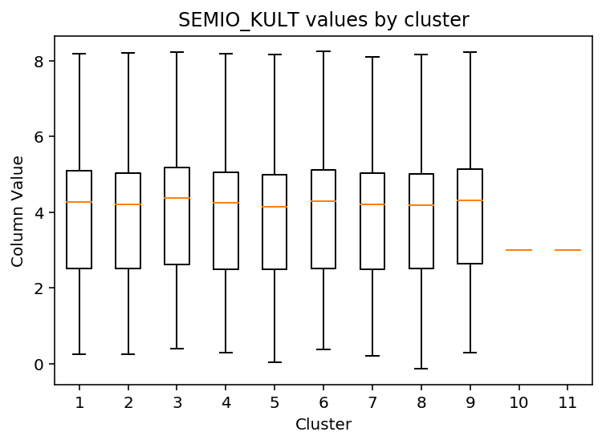

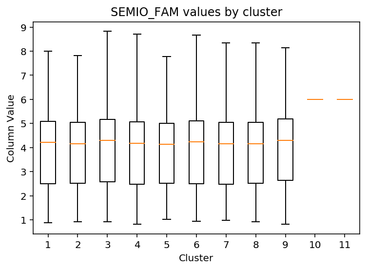

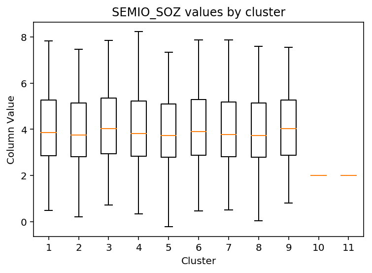

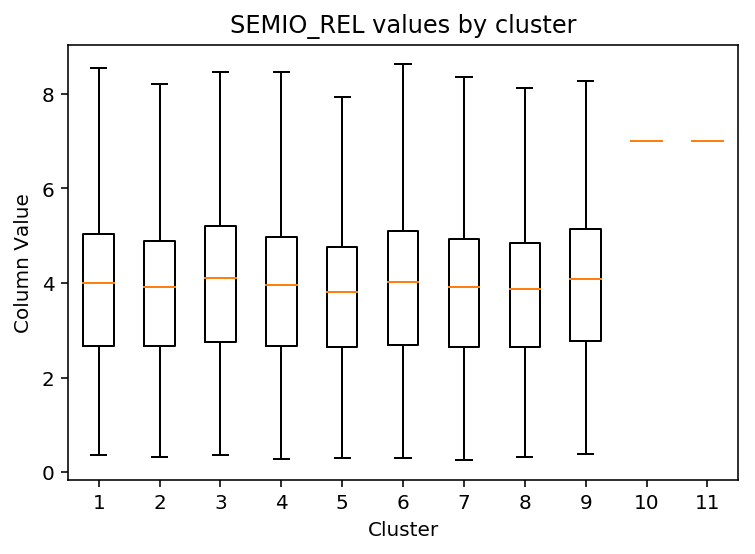

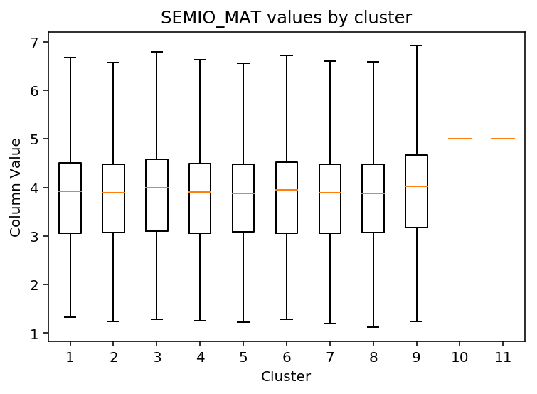

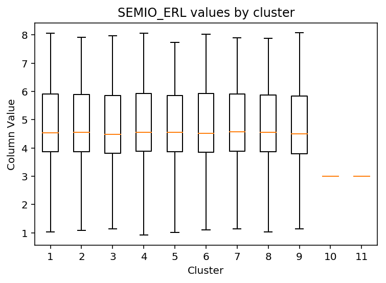

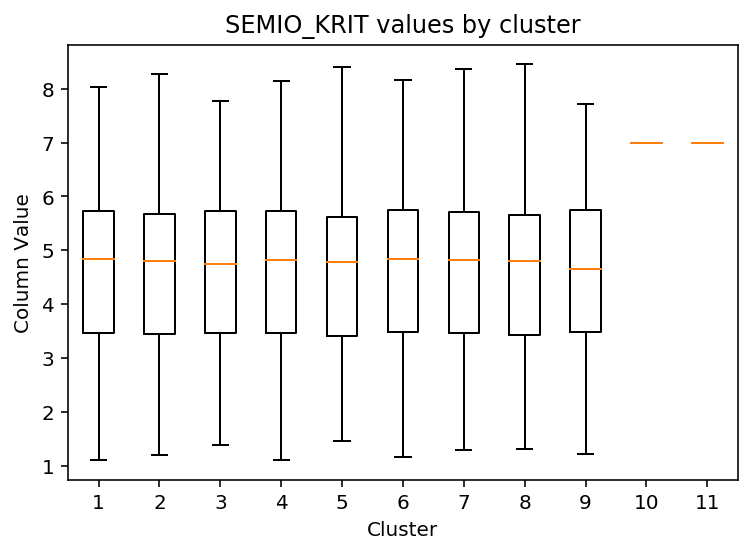

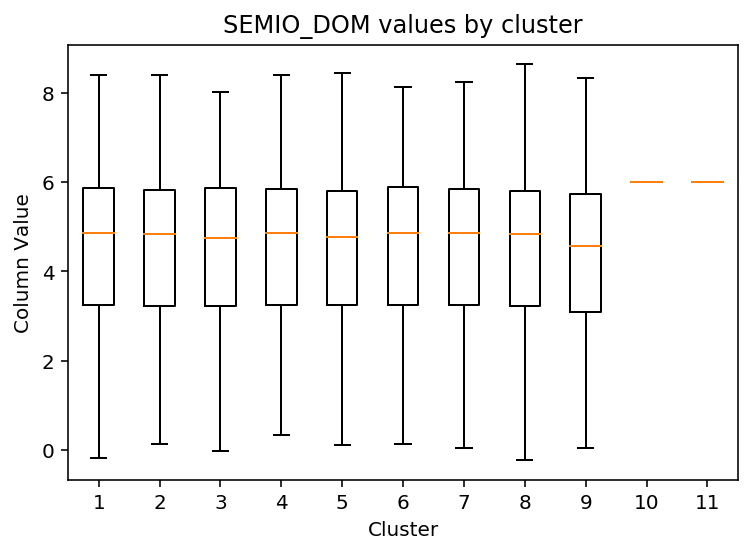

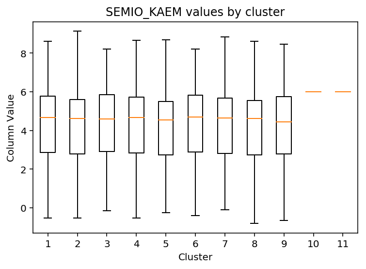

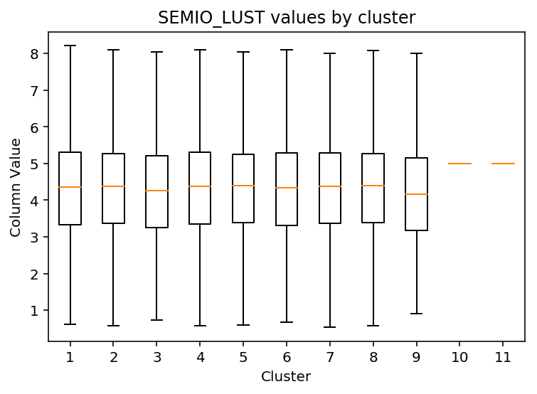

```python
cols_to_compare = ['SEMIO_VERT',
                   'SEMIO_KULT',
                   'SEMIO_FAM',
                   'SEMIO_SOZ',
                   'SEMIO_REL',
                   'SEMIO_MAT',
                   'SEMIO_ERL',
                   'SEMIO_KRIT',
                   'SEMIO_DOM',
                   'SEMIO_KAEM',
                  'SEMIO_LUST']

for col in cols_to_compare:
    get_boxplots(col)
```

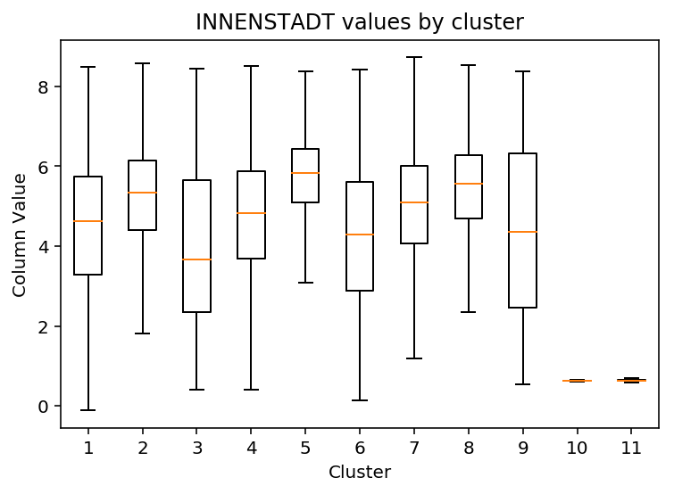

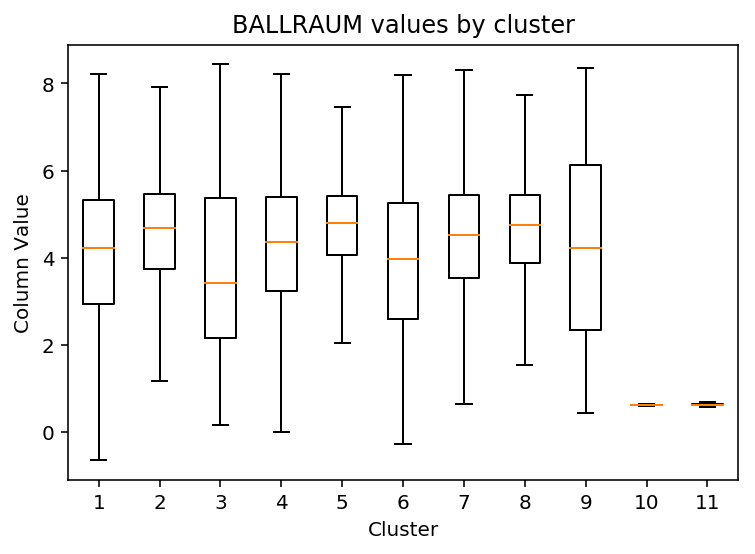

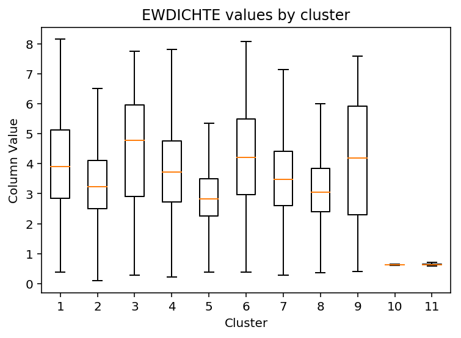

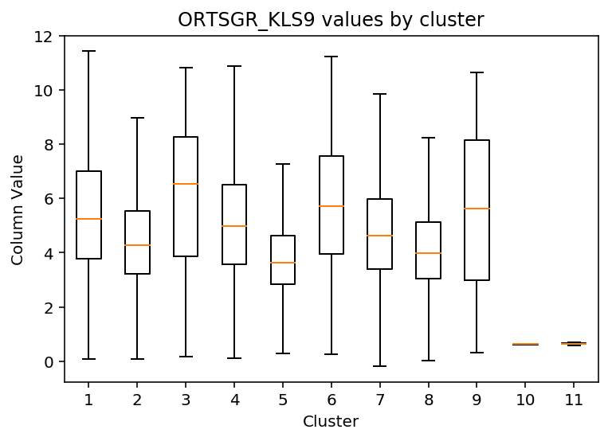

```python
col_urbanity_travel = [
    'INNENSTADT',
    'BALLRAUM',
    'EWDICHTE',
    'ORTSGR_KLS9'
]
for col in col_urbanity_travel:
    get_boxplots(col)
```

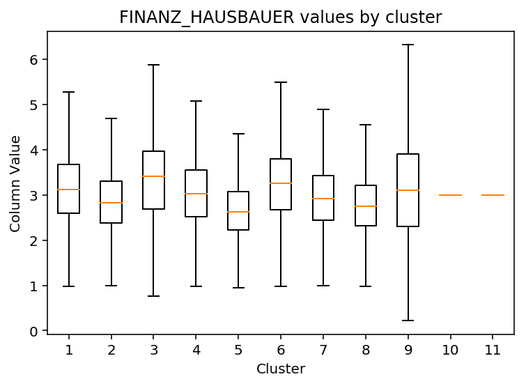

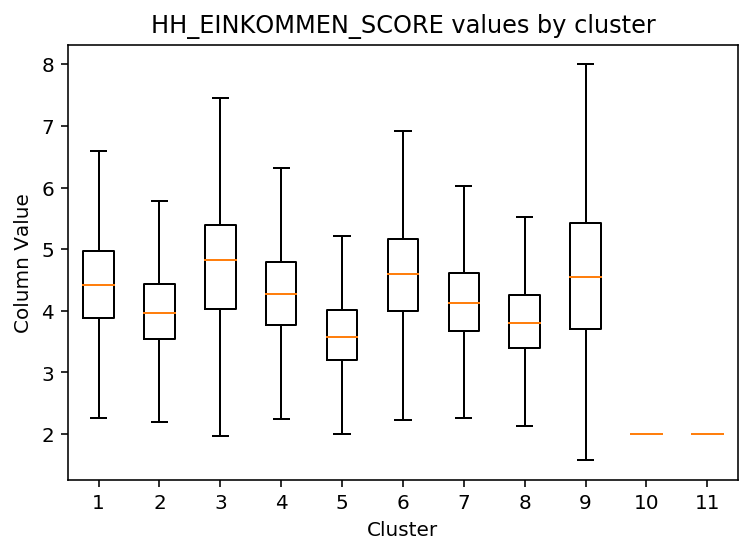

```python
get_boxplots('FINANZ_HAUSBAUER')
get_boxplots('HH_EINKOMMEN_SCORE')
```

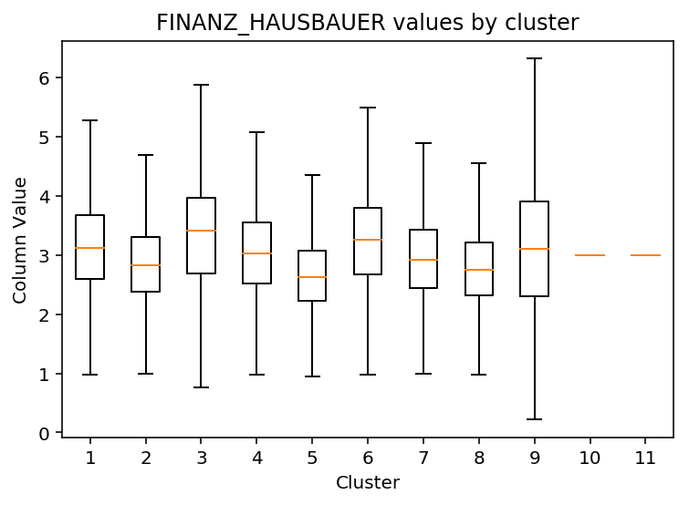

```python
get_boxplots('FINANZ_HAUSBAUER')
```

```python
# What kinds of people are part of a cluster that is overrepresented in the
# customer data compared to the general population?

# They tend to live further from the city center/nearest urban center.
# They tend to live in smaller, less dense communities in buildings with fewer units.
# They are likely to have higher incomes.
```

```python
# What kinds of people are part of a cluster that is underrepresented in the
# customer data compared to the general population?
# Those that are more socially minded tend to be underrepresented in the customer data compared to the general population.
# As well as those with lower income and lower home-ownership scores.
```

### Discussion 3.3: Compare Customer Data to Demographics Data

When I analyzed the data based on my clustering I found that the largest cluster of customers was actually from the rows that I initially excluded. These rows accounted for approximately 25% of the customer data but only around 10% of the population data. When I examined this cluster in both the customer data and the general population data I found that for the features that were included, values were fairly consistent between the two datasets which suggests this was a real cluster. Although it was missing large amounts of data for several features it had many features which were complete or nearly complete. Amoung the features which were useable for analysis there were several features related to personality type and socioeconomic status. Further analysis showed that this cluster consisted of people with a very high income who lived within the city center. This segment consisted of people who are more likely to be dreamful, as well as socially and culturally minded and less likely to be family oriented and religious among other traits. Customers were also enriched to a lesser degree in four other clusters which tended to represent segments of the population that have a higher than average income and who tend to live in smaller, less dense communities that are further from urban centers.  
There were also two clusters that were underrepresented in the customer data. These clusters mapped to segments of the population that tended to have lower income, and lower home-ownership scores. These segments tended to live closer to city centers, in denser communities and often in building with many households (ie large apartment buildings).

> Congratulations on making it this far in the project! Before you finish, make sure to check through the entire notebook from top to bottom to make sure that your analysis follows a logical flow and all of your findings are documented in **Discussion** cells. Once you've checked over all of your work, you should export the notebook as an HTML document to submit for evaluation. You can do this from the menu, navigating to **File -> Download as -> HTML (.html)**. You will submit both that document and this notebook for your project submission.